# IODS course project

Niko Ilomäki

# About the project

A University of Helsinki course about open data science; should be interesting. [More course info here](https://courses.helsinki.fi/78995/115961424)

[Repo link](https://github.com/NVI/IODS-project)

# Linear regression

```r
library(ggplot2)
library(GGally)
```

```r
learning2014 <- read.csv("data/learning2014.csv")
```

We are looking at the dataset learning2014. Here is a summary of the dataset:

```r
str(learning2014)
```

```
## 'data.frame':    166 obs. of  7 variables:
##  $ gender  : Factor w/ 2 levels "F","M": 1 2 1 2 2 1 2 1 2 1 ...
##  $ age     : int  53 55 49 53 49 38 50 37 37 42 ...
##  $ attitude: num  3.7 3.1 2.5 3.5 3.7 3.8 3.5 2.9 3.8 2.1 ...
##  $ deep    : num  3.58 2.92 3.5 3.5 3.67 ...
##  $ stra    : num  3.38 2.75 3.62 3.12 3.62 ...
##  $ surf    : num  2.58 3.17 2.25 2.25 2.83 ...
##  $ points  : int  25 12 24 10 22 21 21 31 24 26 ...
```

This dataset of learning results (as measured by exam points) and possibly explanatory variables consists of 166 observations and 7 variables. Here is a graphical overview of the dataset:

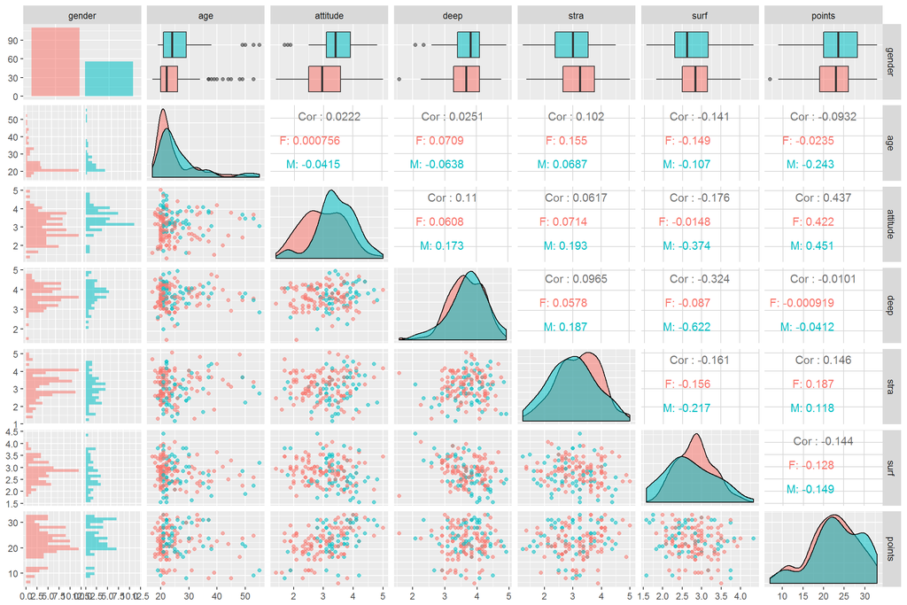

```r
ggpairs(learning2014, mapping = aes(col = gender, alpha = 0.2), lower = list(combo = wrap("facethist", bins = 25)))
```

There is somewhat high correlation between attitude and points, but otherwise the variables are pretty uncorrelated. All variables have mostly similar distributions for both genders. Genders are marked with coloring.

```r
first_model <- lm(learning2014$points ~ learning2014$attitude + learning2014$stra + learning2014$surf)
summary(first_model)
```

```
##
## Call:
## lm(formula = learning2014$points ~ learning2014$attitude + learning2014$stra +
##     learning2014$surf)
##
## Residuals:
##      Min       1Q   Median       3Q      Max
## -17.1550  -3.4346   0.5156   3.6401  10.8952
##
## Coefficients:
##                       Estimate Std. Error t value Pr(>|t|)
## (Intercept)            11.0171     3.6837   2.991  0.00322 **
## learning2014$attitude   3.3952     0.5741   5.913 1.93e-08 ***
## learning2014$stra       0.8531     0.5416   1.575  0.11716
## learning2014$surf      -0.5861     0.8014  -0.731  0.46563
## ---
## Signif. codes:  0 '***' 0.001 '**' 0.01 '*' 0.05 '.' 0.1 ' ' 1
##
## Residual standard error: 5.296 on 162 degrees of freedom
## Multiple R-squared:  0.2074, Adjusted R-squared:  0.1927
## F-statistic: 14.13 on 3 and 162 DF,  p-value: 3.156e-08
```

We first try multiple regression, but strategic and surface learning do not have statistical significance as explainers of exam points. We thus limit ourselves to simple regression with attitude:

```r
second_model <- lm(learning2014$points ~ learning2014$attitude)
summary(second_model)
```

```
##
## Call:
## lm(formula = learning2014$points ~ learning2014$attitude)
##
## Residuals:
##      Min       1Q   Median       3Q      Max
## -16.9763  -3.2119   0.4339   4.1534  10.6645
##
## Coefficients:
##                       Estimate Std. Error t value Pr(>|t|)
## (Intercept)            11.6372     1.8303   6.358 1.95e-09 ***
## learning2014$attitude   3.5255     0.5674   6.214 4.12e-09 ***
## ---
## Signif. codes:  0 '***' 0.001 '**' 0.01 '*' 0.05 '.' 0.1 ' ' 1
##
## Residual standard error: 5.32 on 164 degrees of freedom
## Multiple R-squared:  0.1906, Adjusted R-squared:  0.1856
## F-statistic: 38.61 on 1 and 164 DF,  p-value: 4.119e-09
```

There is very high statistical significance for attitude as explainer of exam points.

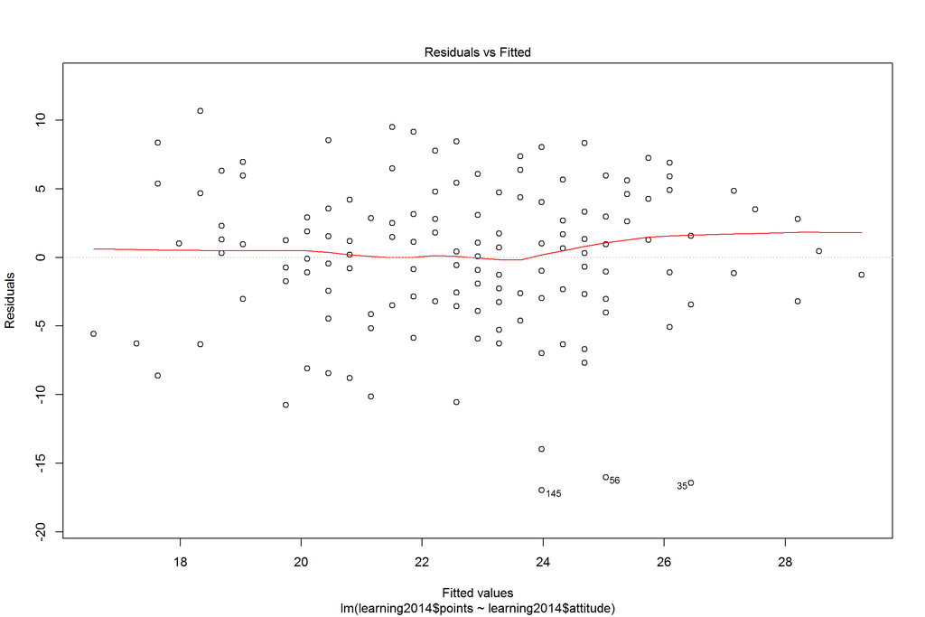

```r
plot(second_model, which = 1)
```

Constant variance of errors assumption holds well.

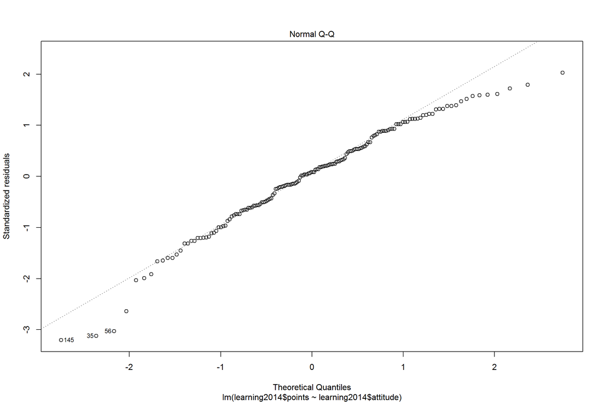

```r
plot(second_model, which = 2)
```

The QQ plot implies that the errors have reasonably normal distribution, though there are some problems in both extremes.

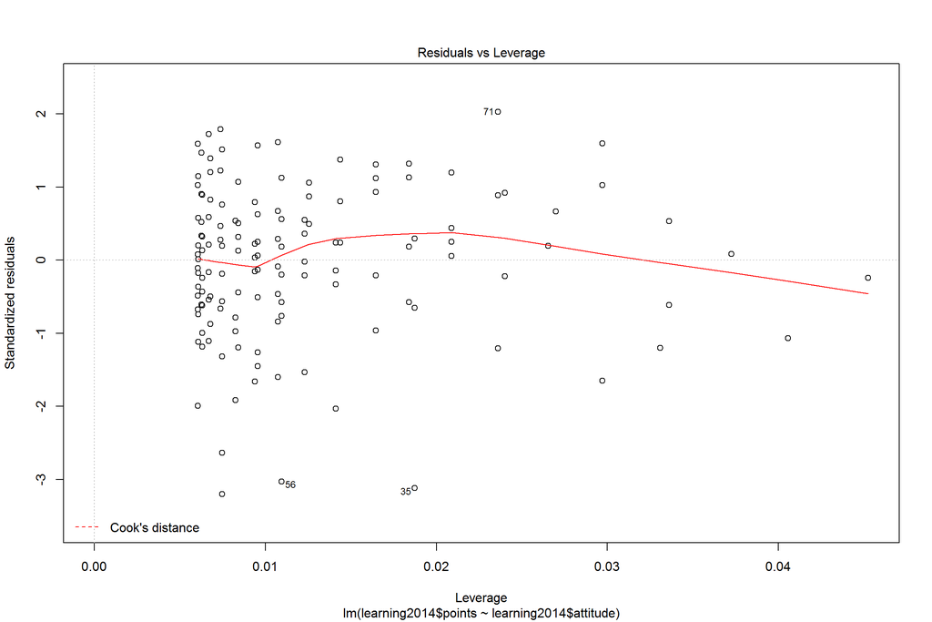

```r
plot(second_model, which = 5)
```

No observation has abnormally large leverage, making the model seem more reasonable.

# Logistic regression

```r
library(tibble)
library(magrittr)
library(boot)
```

```r
alc <- read.csv("data/alc.csv")
```

We are looking at the [UCI Student Alcohol Consumption dataset](https://archive.ics.uci.edu/ml/datasets/STUDENT+ALCOHOL+CONSUMPTION). Here is a glimpse of it:

```r
glimpse(alc)
```

```
## Observations: 382
## Variables: 35
## $ school     <fctr> GP, GP, GP, GP, GP, GP, GP, GP, GP, GP, GP, GP, GP...
## $ sex        <fctr> F, F, F, F, F, M, M, F, M, M, F, F, M, M, M, F, F,...
## $ age        <int> 18, 17, 15, 15, 16, 16, 16, 17, 15, 15, 15, 15, 15,...
## $ address    <fctr> U, U, U, U, U, U, U, U, U, U, U, U, U, U, U, U, U,...
## $ famsize    <fctr> GT3, GT3, LE3, GT3, GT3, LE3, LE3, GT3, LE3, GT3, ...
## $ Pstatus    <fctr> A, T, T, T, T, T, T, A, A, T, T, T, T, T, A, T, T,...
## $ Medu       <int> 4, 1, 1, 4, 3, 4, 2, 4, 3, 3, 4, 2, 4, 4, 2, 4, 4, ...
## $ Fedu       <int> 4, 1, 1, 2, 3, 3, 2, 4, 2, 4, 4, 1, 4, 3, 2, 4, 4, ...
## $ Mjob       <fctr> at_home, at_home, at_home, health, other, services...
## $ Fjob       <fctr> teacher, other, other, services, other, other, oth...
## $ reason     <fctr> course, course, other, home, home, reputation, hom...
## $ nursery    <fctr> yes, no, yes, yes, yes, yes, yes, yes, yes, yes, y...
## $ internet   <fctr> no, yes, yes, yes, no, yes, yes, no, yes, yes, yes...
```

[output cut: 22 more lines]

We will study relationships of high/low alcohol consumption and other variables. For the sake of this exercise, other variables are ‘activities’ (has extracurricular activities), ‘freetime’ (amount of free time after school), ‘goout’ (amount of going out with friends) and ‘health’ (current health status). Working hypothesis would be that an increase in any of the first three or a decrease in the last one implies assumed higher alcohol consumption. The relationships might not be that strong though.

We will first take a look at activities:

```r
table(high_use = alc$high_use, activities = alc$activities)
```

```
##         activities
## high_use  no yes
##    FALSE 122 146
##    TRUE   59  55
```

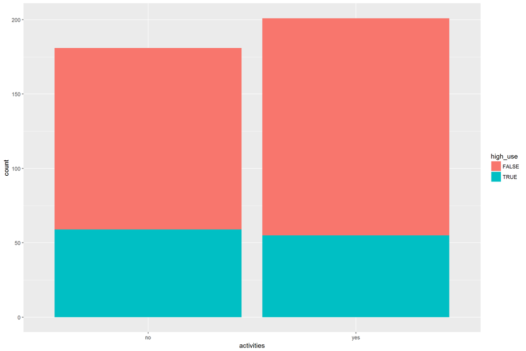

```r
plot(ggplot(alc, aes(x = activities)) + geom_bar(aes(fill = high_use)))
```

Here it seems there is pretty much no relation between high alcohol consumption and extracurricular activies, so the working hypothesis is false; in fact, the small difference in this set of observations actually goes to the opposite direction.

Next we will look at free time:

```r
table(high_use = alc$high_use, freetime = alc$freetime)
```

```
##         freetime
## high_use   1   2   3   4   5
##    FALSE  15  49 113  70  21
##    TRUE    2  16  40  41  15
```

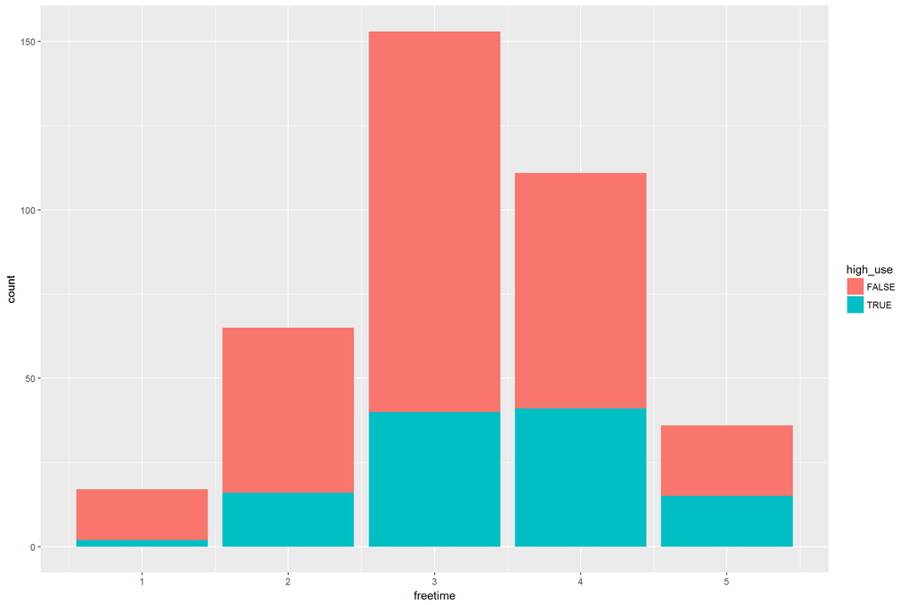

```r
plot(ggplot(alc, aes(x = freetime)) + geom_bar(aes(fill = high_use)))
```

Preliminarily the working hypothesis seems much better here: there are not many students who consume lots of alcohol while not having much free time after school, but considerable portion of the students with the most free time consume lots of alcohol.

Variable that measures going out with friends might behave somewhat similarly, so we will take a look at it:

```r
table(high_use = alc$high_use, goout = alc$goout)
```

```
##         goout
## high_use   1   2   3   4   5
##    FALSE  19  84 103  41  21
##    TRUE    3  16  23  40  32
```

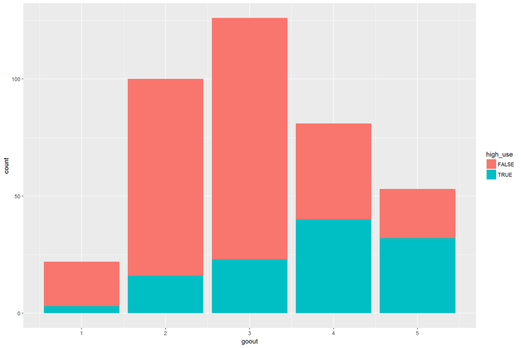

```r
plot(ggplot(alc, aes(x = goout)) + geom_bar(aes(fill = high_use)))
```

Indeed, the first observations are very similar to free time variable and the relationship seems to be even stronger here.

Lastly, we will take a look at health:

```r
table(high_use = alc$high_use, health = alc$health)
```

```
##         health
## high_use  1  2  3  4  5
##    FALSE 35 28 62 49 94
##    TRUE  11 16 19 18 50
```

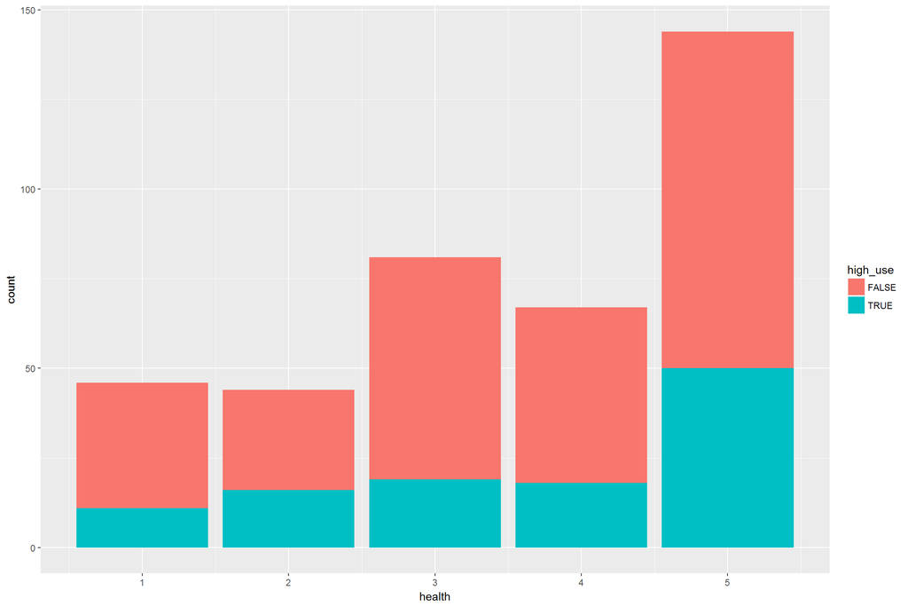

```r
plot(ggplot(alc, aes(x = health)) + geom_bar(aes(fill = high_use)))
```

Here we see that the biggest portion of students with high alcohol consumption actually lies in the top fifth of health status. So it might be that at the age of these students, good health enables high alcohol consumption, while the negative effects of that consumption to health are still negligible.

Overall, the relationship between health and high alcohol consumption seems to be weak here.

We will now fit a logistic regression model with these variables:

```r
m <- glm(high_use ~ activities + freetime + goout + health, data = alc, family = "binomial")
summary(m)
```

```
##
## Call:
## glm(formula = high_use ~ activities + freetime + goout + health,
##     family = "binomial", data = alc)
##
## Deviance Residuals:
##     Min       1Q   Median       3Q      Max
## -1.5632  -0.7963  -0.5724   0.9720   2.4531
##
## Coefficients:
##               Estimate Std. Error z value Pr(>|z|)
## (Intercept)   -3.95200    0.61808  -6.394 1.62e-10 ***
## activitiesyes -0.36329    0.24303  -1.495    0.135
## freetime       0.11856    0.13359   0.888    0.375
## goout          0.74519    0.12172   6.122 9.23e-10 ***
## health         0.12491    0.08824   1.416    0.157
## ---
## Signif. codes:  0 '***' 0.001 '**' 0.01 '*' 0.05 '.' 0.1 ' ' 1
##
## (Dispersion parameter for binomial family taken to be 1)
##
##     Null deviance: 465.68  on 381  degrees of freedom
## Residual deviance: 410.53  on 377  degrees of freedom
## AIC: 420.53
##
## Number of Fisher Scoring iterations: 4
```

Only the variable ‘goout’ has statistically significant relationship with high/low alcohol consumption in this model. We should look at the odds ratios and their confidence intervals:

```r
OR <- coef(m) %>% exp()
CI <- confint(m) %>% exp()
cbind(OR, CI)
```

```
##                       OR       2.5 %     97.5 %
## (Intercept)   0.01921623 0.005488501 0.06222816
## activitiesyes 0.69538475 0.430469070 1.11809527
## freetime      1.12587388 0.866572754 1.46498319
## goout         2.10684951 1.670305678 2.69462900
## health        1.13304588 0.954811883 1.35049332
```

Indeed, confidence intervals for odds ratios of all other variables contain 1, the break-even point so it makes sense that their predictive power would be low. Concerning the working hypothesis, the hypothesis holds for ‘goout’, but other relationships are perhaps even weaker than anticipated, at least in this particular model.

We will now fit a new model with the only significant variable, ‘goout’:

```r
m_goout <- glm(high_use ~ goout, data = alc, family = "binomial")
summary(m_goout)
```

```
##
## Call:
## glm(formula = high_use ~ goout, family = "binomial", data = alc)
##
## Deviance Residuals:
##     Min       1Q   Median       3Q      Max
## -1.3721  -0.7672  -0.5450   0.9945   2.3082
##
## Coefficients:
##             Estimate Std. Error z value Pr(>|z|)
## (Intercept)  -3.3512     0.4151  -8.073 6.84e-16 ***
## goout         0.7596     0.1157   6.564 5.23e-11 ***
## ---
## Signif. codes:  0 '***' 0.001 '**' 0.01 '*' 0.05 '.' 0.1 ' ' 1
##
## (Dispersion parameter for binomial family taken to be 1)
##
##     Null deviance: 465.68  on 381  degrees of freedom
## Residual deviance: 415.68  on 380  degrees of freedom
## AIC: 419.68
##
## Number of Fisher Scoring iterations: 4
```

We will use this model to make predictions:

```r
probabilities <- predict(m_goout, type = "response")
predictions <- (probabilities > 0.5)
table(high_use = alc$high_use, prediction = predictions)
```

```
##         prediction
## high_use FALSE TRUE
##    FALSE   247   21
##    TRUE     82   32
```

103 predictions out of 382 were wrong, so the predictive power is not especially high even if it is better than a simple coin flip.

Lastly, we will try cross validation:

```r
# loss_func from DataCamp exercises
loss_func <- function(class, prob) {
  n_wrong <- abs(class - prob) > 0.5
  mean(n_wrong)
}

cv <- cv.glm(data = alc, cost = loss_func, glmfit = m_goout, K = 10)

cv$delta[1]
```

```
## [1] 0.2696335
```

The model has about the same performance as the one in DataCamp exercises, but using just one variable for predictions.

# Clustering and classification

```r
library(MASS)
library(magrittr)
library(dplyr)
library(ggplot2)
```

```r
data("Boston")
```

We are looking at the “Housing Values in Suburbs of Boston” dataset from the MASS package.

```r
str(Boston)
```

```
## 'data.frame':    506 obs. of  14 variables:
##  $ crim   : num  0.00632 0.02731 0.02729 0.03237 0.06905 ...
##  $ zn     : num  18 0 0 0 0 0 12.5 12.5 12.5 12.5 ...
##  $ indus  : num  2.31 7.07 7.07 2.18 2.18 2.18 7.87 7.87 7.87 7.87 ...
##  $ chas   : int  0 0 0 0 0 0 0 0 0 0 ...
##  $ nox    : num  0.538 0.469 0.469 0.458 0.458 0.458 0.524 0.524 0.524 0.524 ...
##  $ rm     : num  6.58 6.42 7.18 7 7.15 ...
##  $ age    : num  65.2 78.9 61.1 45.8 54.2 58.7 66.6 96.1 100 85.9 ...
##  $ dis    : num  4.09 4.97 4.97 6.06 6.06 ...
##  $ rad    : int  1 2 2 3 3 3 5 5 5 5 ...
##  $ tax    : num  296 242 242 222 222 222 311 311 311 311 ...
##  $ ptratio: num  15.3 17.8 17.8 18.7 18.7 18.7 15.2 15.2 15.2 15.2 ...
##  $ black  : num  397 397 393 395 397 ...
##  $ lstat  : num  4.98 9.14 4.03 2.94 5.33 ...
##  $ medv   : num  24 21.6 34.7 33.4 36.2 28.7 22.9 27.1 16.5 18.9 ...
```

```r
summary(Boston)
```

```
##       crim                zn             indus            chas
##  Min.   : 0.00632   Min.   :  0.00   Min.   : 0.46   Min.   :0.00000
##  1st Qu.: 0.08204   1st Qu.:  0.00   1st Qu.: 5.19   1st Qu.:0.00000
##  Median : 0.25651   Median :  0.00   Median : 9.69   Median :0.00000
##  Mean   : 3.61352   Mean   : 11.36   Mean   :11.14   Mean   :0.06917
##  3rd Qu.: 3.67708   3rd Qu.: 12.50   3rd Qu.:18.10   3rd Qu.:0.00000
##  Max.   :88.97620   Max.   :100.00   Max.   :27.74   Max.   :1.00000
##       nox               rm             age              dis
##  Min.   :0.3850   Min.   :3.561   Min.   :  2.90   Min.   : 1.130
##  1st Qu.:0.4490   1st Qu.:5.886   1st Qu.: 45.02   1st Qu.: 2.100
##  Median :0.5380   Median :6.208   Median : 77.50   Median : 3.207
##  Mean   :0.5547   Mean   :6.285   Mean   : 68.57   Mean   : 3.795
##  3rd Qu.:0.6240   3rd Qu.:6.623   3rd Qu.: 94.08   3rd Qu.: 5.188
##  Max.   :0.8710   Max.   :8.780   Max.   :100.00   Max.   :12.127
##       rad              tax           ptratio          black
##  Min.   : 1.000   Min.   :187.0   Min.   :12.60   Min.   :  0.32
##  1st Qu.: 4.000   1st Qu.:279.0   1st Qu.:17.40   1st Qu.:375.38
##  Median : 5.000   Median :330.0   Median :19.05   Median :391.44
##  Mean   : 9.549   Mean   :408.2   Mean   :18.46   Mean   :356.67
##  3rd Qu.:24.000   3rd Qu.:666.0   3rd Qu.:20.20   3rd Qu.:396.23
##  Max.   :24.000   Max.   :711.0   Max.   :22.00   Max.   :396.90
##      lstat            medv
##  Min.   : 1.73   Min.   : 5.00
##  1st Qu.: 6.95   1st Qu.:17.02
##  Median :11.36   Median :21.20
##  Mean   :12.65   Mean   :22.53
##  3rd Qu.:16.95   3rd Qu.:25.00
##  Max.   :37.97   Max.   :50.00
```

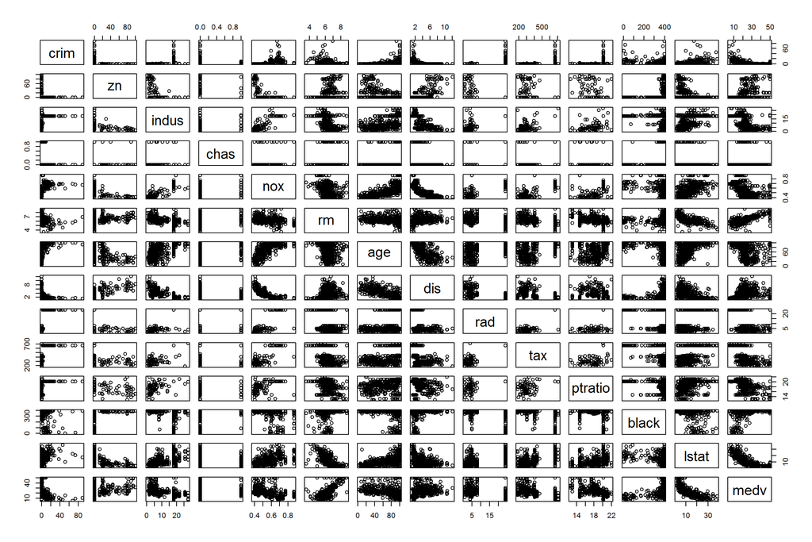

```r
pairs(Boston)
```

We will now standardize the dataset and transform crime rate variable into a categorical one:

```r
boston_scaled <- as.data.frame(scale(Boston))
summary(boston_scaled)
```

```
##       crim                 zn               indus
##  Min.   :-0.419367   Min.   :-0.48724   Min.   :-1.5563
##  1st Qu.:-0.410563   1st Qu.:-0.48724   1st Qu.:-0.8668
##  Median :-0.390280   Median :-0.48724   Median :-0.2109
##  Mean   : 0.000000   Mean   : 0.00000   Mean   : 0.0000
##  3rd Qu.: 0.007389   3rd Qu.: 0.04872   3rd Qu.: 1.0150
##  Max.   : 9.924110   Max.   : 3.80047   Max.   : 2.4202
##       chas              nox                rm               age
##  Min.   :-0.2723   Min.   :-1.4644   Min.   :-3.8764   Min.   :-2.3331
##  1st Qu.:-0.2723   1st Qu.:-0.9121   1st Qu.:-0.5681   1st Qu.:-0.8366
##  Median :-0.2723   Median :-0.1441   Median :-0.1084   Median : 0.3171
##  Mean   : 0.0000   Mean   : 0.0000   Mean   : 0.0000   Mean   : 0.0000
##  3rd Qu.:-0.2723   3rd Qu.: 0.5981   3rd Qu.: 0.4823   3rd Qu.: 0.9059
##  Max.   : 3.6648   Max.   : 2.7296   Max.   : 3.5515   Max.   : 1.1164
##       dis               rad               tax             ptratio
##  Min.   :-1.2658   Min.   :-0.9819   Min.   :-1.3127   Min.   :-2.7047
##  1st Qu.:-0.8049   1st Qu.:-0.6373   1st Qu.:-0.7668   1st Qu.:-0.4876
##  Median :-0.2790   Median :-0.5225   Median :-0.4642   Median : 0.2746
##  Mean   : 0.0000   Mean   : 0.0000   Mean   : 0.0000   Mean   : 0.0000
##  3rd Qu.: 0.6617   3rd Qu.: 1.6596   3rd Qu.: 1.5294   3rd Qu.: 0.8058
##  Max.   : 3.9566   Max.   : 1.6596   Max.   : 1.7964   Max.   : 1.6372
##      black             lstat              medv
##  Min.   :-3.9033   Min.   :-1.5296   Min.   :-1.9063
##  1st Qu.: 0.2049   1st Qu.:-0.7986   1st Qu.:-0.5989
##  Median : 0.3808   Median :-0.1811   Median :-0.1449
##  Mean   : 0.0000   Mean   : 0.0000   Mean   : 0.0000
##  3rd Qu.: 0.4332   3rd Qu.: 0.6024   3rd Qu.: 0.2683
##  Max.   : 0.4406   Max.   : 3.5453   Max.   : 2.9865
```

```r
boston_scaled %<>%
  mutate(
    crim = cut(crim, breaks = quantile(crim), label = c("l", "ml", "mh", "h"), include.lowest = TRUE)
  )
```

After standardization, all variables have mean 0 and variance 1.

For linear discriminant analysis, we will assign 80% of the data to a train set and the rest to a test set:

```r
idx_sample <- sample(nrow(boston_scaled), .8*nrow(boston_scaled))
train <- boston_scaled[idx_sample, ]
test <- boston_scaled[-idx_sample, ]
```

Next we fit the linear discriminant analysis for the categorical crime rate variable:

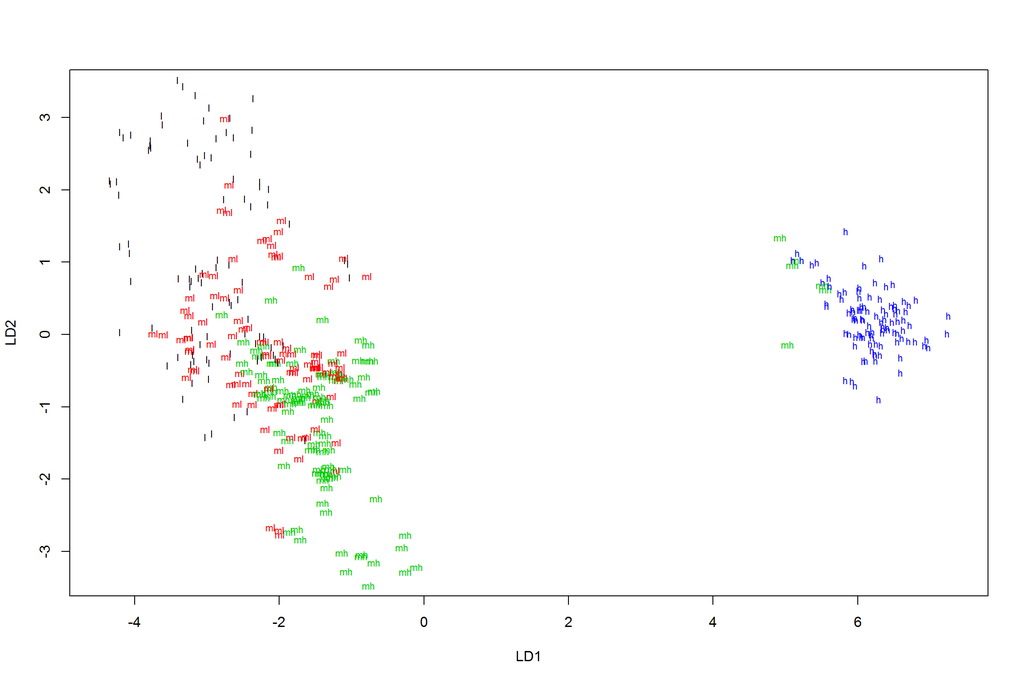

```r
lda.fit <- lda(crim ~ ., data = train)
plot(lda.fit, dimen = 2, col = as.numeric(train$crim))
```

Using the LDA we will try to predict crime rates for the test set:

```r
crime_observed <- test$crim
train %<>% dplyr::select(-crim)
crime_predicted <- predict(lda.fit, newdata = test)
table(crime_observed, crime_predicted$class)
```

```
##
## crime_observed  l ml mh  h
##             l  11 17  3  0
##             ml  6 17  4  0
##             mh  0  0 17  0
##             h   0  0  1 26
```

The predictions are good and only very rarely more than one category away from observed.

Finally we will try clustering with the k-means method:

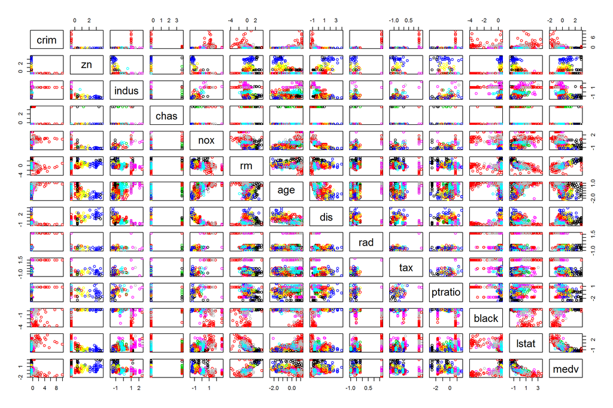

```r
# no need to reload Boston dataset since we have not edited it at all
boston_kmeans <- as.data.frame(scale(Boston))
boston_dist <- dist(boston_kmeans)
km <- kmeans(boston_dist, centers = 10)
pairs(boston_kmeans, col = km$cluster)
```

10 clusters is probably too much, so we will want to see how good results are with less clusters:

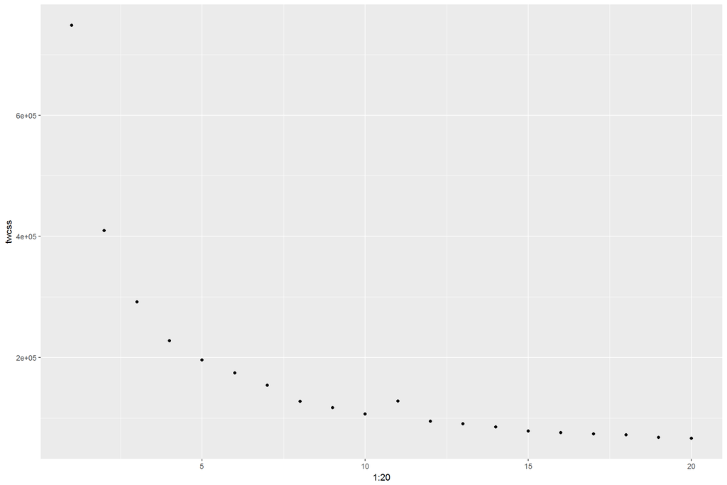

```r
twcss <- sapply(1:20, function(.) {kmeans(boston_dist, .)$tot.withinss})
qplot(1:20, twcss)
```

2 clusters already gives good results, but there seems to be value in going for 3 or maybe even 4 clusters. We will run the algorithm again for 4 clusters and visualize:

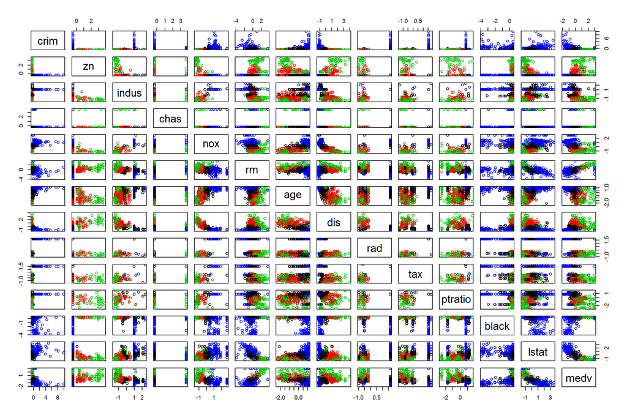

```r
km4 <- kmeans(boston_dist, centers = 4)
pairs(boston_kmeans, col = km4$cluster)
```

We can also look at LDA for these clusters:

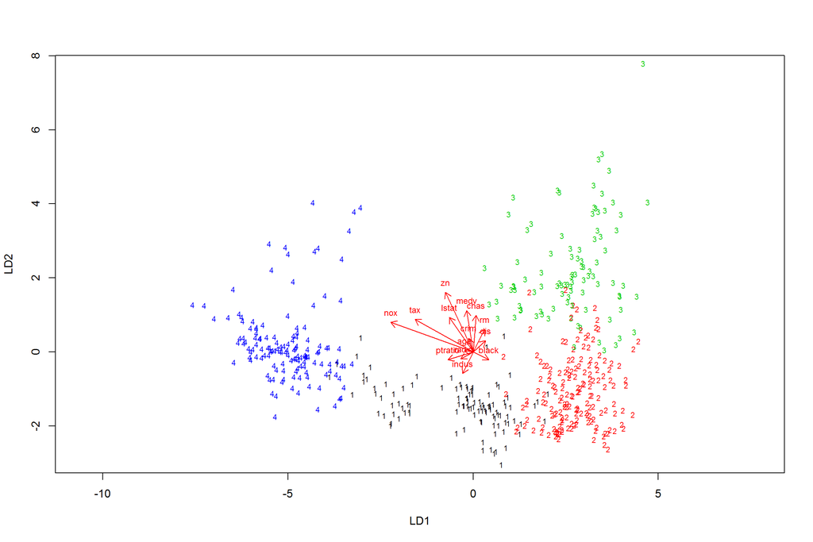

```r
# arrows function from DataCamp exercises
# based originally on this one here:
# http://stackoverflow.com/questions/17232251/how-can-i-plot-a-biplot-for-lda-in-r
lda.arrows <- function(x, myscale = 1, arrow_heads = 0.1, color = "red", tex = 0.75, choices = c(1,2)){
  heads <- coef(x)
  arrows(x0 = 0, y0 = 0,
         x1 = myscale * heads[,choices[1]],
         y1 = myscale * heads[,choices[2]], col=color, length = arrow_heads)
  text(myscale * heads[,choices], labels = row.names(heads),
       cex = tex, col=color, pos=3)
}

boston_kmeans$cluster <- km4$cluster
lda.cluster <- lda(cluster ~ ., data = boston_kmeans)
plot(lda.cluster, dimen = 2, col = km4$cluster)
lda.arrows(lda.cluster, myscale = 1.5)
```

# Dimensionality reduction techniques

```r
library(magrittr)
library(dplyr)
library(ggplot2)
library(FactoMineR)
```

```r
human <- readRDS("data/human.Rds")
```

We are looking at subset of the United Nations’ Human Development Index (HDI) and Gender Inequality Index (GII) data.

```r
str(human)
```

```
## 'data.frame':    155 obs. of  8 variables:
##  $ secondary_education_rate    : num  1.007 0.997 0.983 0.989 0.969 ...
##  $ labour_force_rate           : num  0.891 0.819 0.825 0.884 0.829 ...
##  $ expected_education          : num  17.5 20.2 15.8 18.7 17.9 16.5 18.6 16.5 15.9 19.2 ...
##  $ life_expectancy             : num  81.6 82.4 83 80.2 81.6 80.9 80.9 79.1 82 81.8 ...
##  $ gni_per_capita              : num  64992 42261 56431 44025 45435 ...
##  $ maternal_mortality          : int  4 6 6 5 6 7 9 28 11 8 ...
##  $ adolescent_birth            : num  7.8 12.1 1.9 5.1 6.2 3.8 8.2 31 14.5 25.3 ...
##  $ parliamentary_representation: num  39.6 30.5 28.5 38 36.9 36.9 19.9 19.4 28.2 31.4 ...
```

The data has 8 variables:

- secondary_education_rate: percentage of women with secondary education divided by percentage of men with secondary education
- labour_force_rate: as above, but for labor force participation
- expected_education: expected years of education for children at school entrance age
- life_expectancy: life expectancy for newly born children
- gni_per_capita: gross national income (GNI) per capita
- maternal_mortality: number of maternal deaths per 100 000 births
- adolescent_birth: number of births per 1000 women aged 15-19
- parliamentary_representation: percentage of women in parliament (not sure how this is calculated for non-democracies)

```r
summary(human)
```

```
##  secondary_education_rate labour_force_rate expected_education
##  Min.   :0.1717           Min.   :0.1857    Min.   : 5.40
##  1st Qu.:0.7264           1st Qu.:0.5984    1st Qu.:11.25
##  Median :0.9375           Median :0.7535    Median :13.50
##  Mean   :0.8529           Mean   :0.7074    Mean   :13.18
##  3rd Qu.:0.9968           3rd Qu.:0.8535    3rd Qu.:15.20
##  Max.   :1.4967           Max.   :1.0380    Max.   :20.20
##  life_expectancy gni_per_capita   maternal_mortality adolescent_birth
##  Min.   :49.00   Min.   :   581   Min.   :   1.0     Min.   :  0.60
##  1st Qu.:66.30   1st Qu.:  4198   1st Qu.:  11.5     1st Qu.: 12.65
##  Median :74.20   Median : 12040   Median :  49.0     Median : 33.60
##  Mean   :71.65   Mean   : 17628   Mean   : 149.1     Mean   : 47.16
##  3rd Qu.:77.25   3rd Qu.: 24512   3rd Qu.: 190.0     3rd Qu.: 71.95
##  Max.   :83.50   Max.   :123124   Max.   :1100.0     Max.   :204.80
##  parliamentary_representation
##  Min.   : 0.00
##  1st Qu.:12.40
##  Median :19.30
##  Mean   :20.91
##  3rd Qu.:27.95
##  Max.   :57.50
```

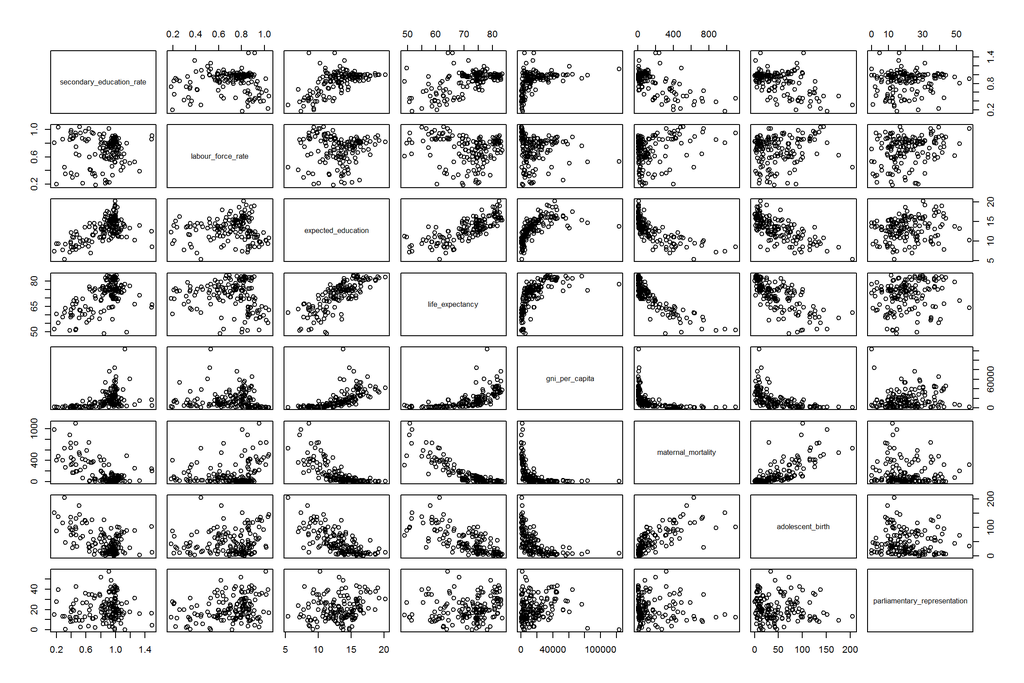

```r
pairs(human)
```

```r
pca_human <- prcomp(human)
summary(pca_human)
```

```
## Importance of components:
##                              PC1      PC2   PC3   PC4   PC5   PC6    PC7
## Standard deviation     1.854e+04 185.5219 25.19 11.45 3.766 1.566 0.1912
## Proportion of Variance 9.999e-01   0.0001  0.00  0.00 0.000 0.000 0.0000
## Cumulative Proportion  9.999e-01   1.0000  1.00  1.00 1.000 1.000 1.0000
##                           PC8
## Standard deviation     0.1591
## Proportion of Variance 0.0000
## Cumulative Proportion  1.0000
```

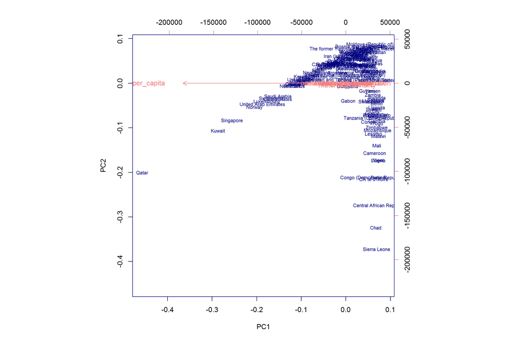

```r
biplot(pca_human, cex = c(0.7, 1), col = c("navy", "lightcoral"))
```

In the case of nonstandardized data, the variable ‘gni_per_capita’ dominates the analysis capturing more than 99.9% of the variance. This is because it has by far the largest mean and variance in absolute terms. This also renders the whole analysis meaningless, so we should focus on the case with standardized variables:

```r
pca_human_scaled <- prcomp(scale(human))
summary(pca_human_scaled)
```

```
## Importance of components:
##                           PC1    PC2     PC3     PC4     PC5     PC6
## Standard deviation     2.0708 1.1397 0.87505 0.77886 0.66196 0.53631
## Proportion of Variance 0.5361 0.1624 0.09571 0.07583 0.05477 0.03595
## Cumulative Proportion  0.5361 0.6984 0.79413 0.86996 0.92473 0.96069
##                            PC7     PC8
## Standard deviation     0.45900 0.32224
## Proportion of Variance 0.02634 0.01298
## Cumulative Proportion  0.98702 1.00000
```

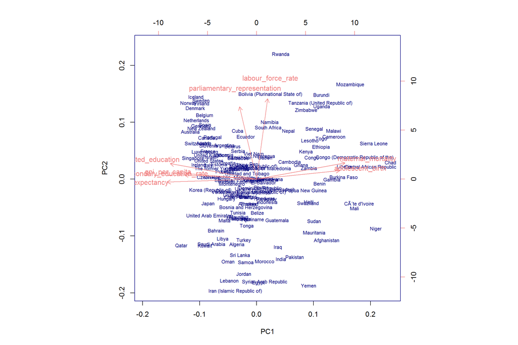

```r
biplot(pca_human_scaled, cex = c(0.7, 1), col = c("navy", "lightcoral"))
```

With standardized variables, a more interesting picture emerges. Especially, here all 8 original variables are almost parallel to one of the axes (principal components) so it seems reasonable to think there could be a tangible link between the principal components and real world.

The first principal component has high positive correlation with maternal mortality and adolescent births, and high negative correlation with life expectancy, GNI per capita, expected years of education, and female education compared to male education. This component could be interpreted as the kind of means the country has to provide an environment of gender equality.

The second principal component has high positive correlation with female parliamentary representation and labour force participation compared to corresponding figures for men. This component could be interpreted as how gender equality actually materializes given the means.

Countries at the far ends include Nordic countries and the Low Countries (high means, high materialization), Middle Eastern OPEC countries (high means, low materialization) and West, Central and East African countries with low means but differing levels of materialization.

Lastly we will take a look at six basically randomly chosen columns from the tea drinking data that comes with FactoMineR package.

```r
data(tea)
tea_part <- tea %>% select(Tea, sugar, friends, spirituality, feminine, relaxing)
```

```r
str(tea_part)
```

```
## 'data.frame':    300 obs. of  6 variables:
##  $ Tea         : Factor w/ 3 levels "black","Earl Grey",..: 1 1 2 2 2 2 2 1 2 1 ...
##  $ sugar       : Factor w/ 2 levels "No.sugar","sugar": 2 1 1 2 1 1 1 1 1 1 ...
##  $ friends     : Factor w/ 2 levels "friends","Not.friends": 2 2 1 2 2 2 1 2 2 2 ...
##  $ spirituality: Factor w/ 2 levels "Not.spirituality",..: 1 1 1 2 2 1 1 1 1 1 ...
##  $ feminine    : Factor w/ 2 levels "feminine","Not.feminine": 2 2 2 2 2 2 2 1 2 2 ...
##  $ relaxing    : Factor w/ 2 levels "No.relaxing",..: 1 1 2 2 2 2 2 2 2 2 ...
```

```r
summary(tea_part)
```

```
##         Tea           sugar            friends              spirituality
##  black    : 74   No.sugar:155   friends    :196   Not.spirituality:206
##  Earl Grey:193   sugar   :145   Not.friends:104   spirituality    : 94
##  green    : 33
##          feminine          relaxing
##  feminine    :129   No.relaxing:113
##  Not.feminine:171   relaxing   :187
##
```

We will experiment with multiple correspondence analysis (MCA) using these columns:

```r
mca_tea <- MCA(tea_part, graph = FALSE)
summary(mca_tea)
```

```
##
## Call:
## MCA(X = tea_part, graph = FALSE)
##
##
## Eigenvalues
##                        Dim.1   Dim.2   Dim.3   Dim.4   Dim.5   Dim.6
## Variance               0.235   0.186   0.177   0.168   0.152   0.141
## % of var.             20.128  15.962  15.134  14.377  13.048  12.052
## Cumulative % of var.  20.128  36.090  51.225  65.602  78.650  90.701
##                        Dim.7
## Variance               0.108
## % of var.              9.299
## Cumulative % of var. 100.000
##
## Individuals (the 10 first)
##                     Dim.1    ctr   cos2    Dim.2    ctr   cos2    Dim.3
## 1                |  0.651  0.601  0.286 | -0.129  0.030  0.011 | -0.465
## 2                |  1.038  1.530  0.740 | -0.242  0.105  0.040 | -0.157
## 3                | -0.052  0.004  0.004 | -0.371  0.246  0.215 | -0.203
## 4                | -0.539  0.413  0.247 |  0.107  0.021  0.010 |  0.018
## 5                | -0.152  0.033  0.020 | -0.005  0.000  0.000 |  0.326
## 6                |  0.240  0.082  0.067 | -0.151  0.041  0.026 | -0.057
## 7                | -0.052  0.004  0.004 | -0.371  0.246  0.215 | -0.203
## 8                |  0.656  0.611  0.313 | -0.414  0.306  0.124 |  0.702
## 9                |  0.240  0.082  0.067 | -0.151  0.041  0.026 | -0.057
## 10               |  0.722  0.740  0.407 | -0.638  0.730  0.318 |  0.183
##                     ctr   cos2
## 1                 0.409  0.146 |
## 2                 0.047  0.017 |
## 3                 0.078  0.064 |
## 4                 0.001  0.000 |
## 5                 0.201  0.092 |
## 6                 0.006  0.004 |
## 7                 0.078  0.064 |
## 8                 0.930  0.358 |
## 9                 0.006  0.004 |
## 10                0.063  0.026 |
##
## Categories (the 10 first)
```

[output cut: 16 more lines]

```
## sugar              0.021   2.524 |  -0.402   7.357   0.151  -6.716 |
## friends            0.073  -4.681 |  -0.127   1.002   0.031  -3.026 |
## Not.friends        0.073   4.681 |   0.240   1.889   0.031   3.026 |
## Not.spirituality   0.031  -3.031 |  -0.303   5.935   0.201  -7.746 |
## spirituality       0.031   3.031 |   0.663  13.005   0.201   7.746 |
## feminine           0.083   4.985 |   0.746  22.590   0.420  11.204 |
##
## Categorical variables (eta2)
##                    Dim.1 Dim.2 Dim.3
## Tea              | 0.442 0.661 0.085 |
## sugar            | 0.317 0.021 0.151 |
## friends          | 0.164 0.073 0.031 |
## spirituality     | 0.279 0.031 0.201 |
## feminine         | 0.009 0.083 0.420 |
## relaxing         | 0.198 0.248 0.172 |
```

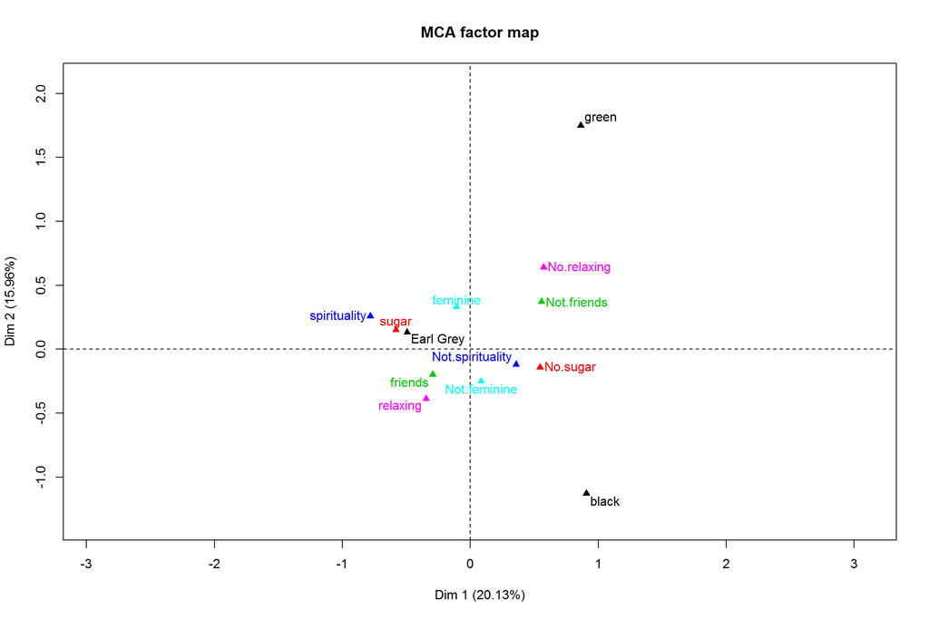

```r
plot(mca_tea, invisible=c("ind"), habillage = "quali")
```

Earl Grey is very similar to spirituality, friends, relaxation and femininity. Green and black, while outliers altogether, are more similar to the opposites. I am at a loss for a sociological or nutritional explanation.